# Szeregi czasowe - Projekt zaliczeniowy

Mateusz Rup

# Analiza dwóch szeregów czasowych

## Pierwszy szereg z trenedem

Analiza problemów związanych z danymi dotyczącymi bankowego kredytu jest istotna dla zrozumienia tendencji w sektorze finansowym i podejmowania informowanych decyzji. Dane Bank Credit, All Commercial Banks, dotyczą ogólnej wielkości kredytów przyznanych przez wszystkie komercyjne banki. Dlaczego to istotne zagadnienie? Kredyt jest kluczowym elementem funkcjonowania gospodarki. Dynamika zmian w poziomie kredytu może dostarczać informacji o aktywności gospodarcze oraz kondycji sektora bankowego. Korzyści wynikające z trafnych prognoz to na przykład, instytucje finansowe mogą wykorzystać prognozy do podejmowania decyzji dotyczących alokacji kapitału, zarządzania ryzykiem kredytowym i opracowywania strategii biznesowych.Dane dotyczące Bank Credit, All Commercial Banks są dostarczane przez Federal Reserve Economic Data (FRED) i obejmują określony okres czasu. (https://fred.stlouisfed.org/series/LOANINV)

## Drugi szereg z sezonowością

Analizowane zagadnienie dotyczy Harmonized Index of Consumer Prices (HICP) dla sezonowych artykułów spożywczych w Polsce. HICP to wskaźnik cen, który mierzy zmiany cen towarów i usług konsumpcyjnych w czasie.Analiza zmian cen sezonowych artykułów spożywczych może dostarczyć informacji o trendach konsumpcyjnych i preferencjach konsumentów w różnych okresach roku. Może to pomóc przedsiębiorcom i producentom w podejmowaniu decyzji dotyczących produkcji. Analiza danych HICP dla sezonowych artykułów spożywczych może dostarczyć wglądu w dynamikę cen i trendów konsumpcyjnych w Polsce. Trafne prognozy zmian cen mogą przynieść korzyści ekonomiczne, takie jak lepsze planowanie budżetu.Dane dotyczące Harmonized Index of Consumer Prices: Seasonal Food for Poland są dostarczane przez Federal Reserve Economic Data (FRED) i obejmują określony okres czasu. (https://fred.stlouisfed.org/series/SEAS00PLM086NEST)

### Wczytanie danych oraz potrzebnych bibliotek

```r
library(tidyverse)
library(ggfortify)
library(forecast)
library(lattice)
sztre <- read.csv("LOANINV.csv", header = T, sep = ",")
tstre <-  ts(sztre$LOANINV, start=c(1996,1), frequency = 12)
szsez <- read.csv("SEAS00PLM086NEST.csv", header = T, sep = ",")
tssez <- ts(szsez$SEAS00PLM086NEST, start=c(1996,1), frequency = 12)
#Sprawdzenie czy sa szeragami czasowymi
(is.ts(tstre))
```

```
## [1] TRUE
```

```r
(is.ts(tssez))
```

```
## [1] TRUE
```

## Wykresy

### Wykresy dla szeregu z trendem

#### Wykres czasowy

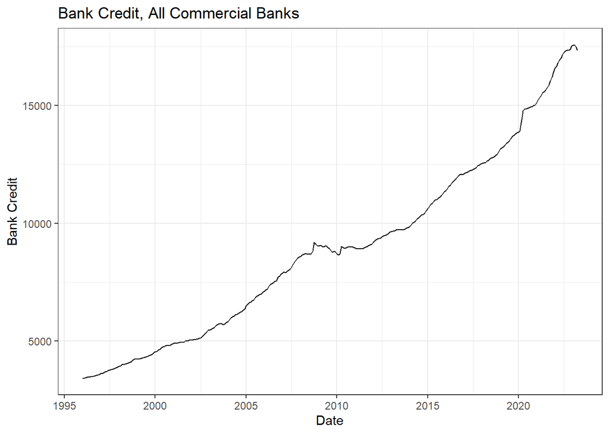

```r
autoplot(tstre, xlab = "Date", ylab = "Bank Credit", main = "Bank Credit, All Commercial Banks") + theme_bw()
```

Patrząc na wykres możemy zobaczyć, że od roku 1996 wartość kredytów udzielanych przez komercyjne banki zwiększyła się kilku krotnie w porównaniu do 2023

#### Acf

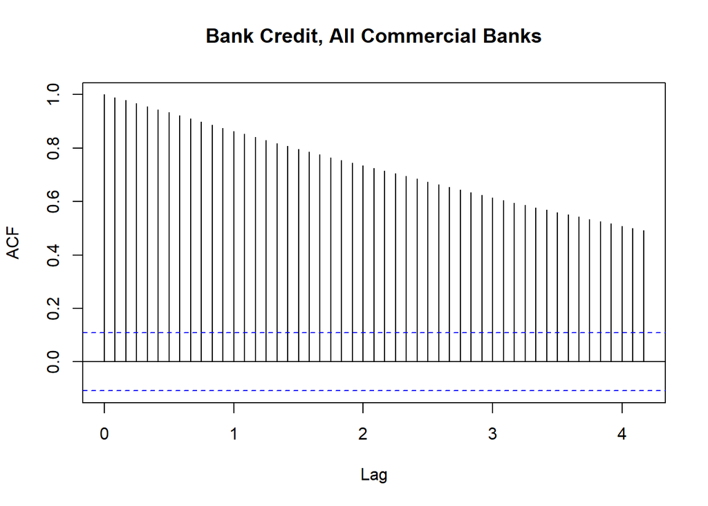

```r
acf(tstre, lag.max = 50, main = "Bank Credit, All Commercial Banks")
```

Wykres ten wskazuje na trend wzrostowy, ponieważ wartości są dodatnie. Bardzo powoli maleją. Nie ma sezonowości.

#### Pacf

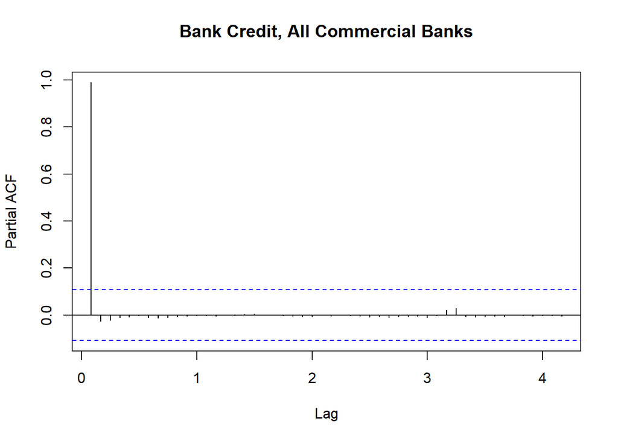

```r
pacf(tstre, lag.max = 50, main = "Bank Credit, All Commercial Banks")
```

Bardzo silny trend (szpilka w 1). Inne wartości mieszczą się w przedziale ufności.

#### Wykres miesięczny

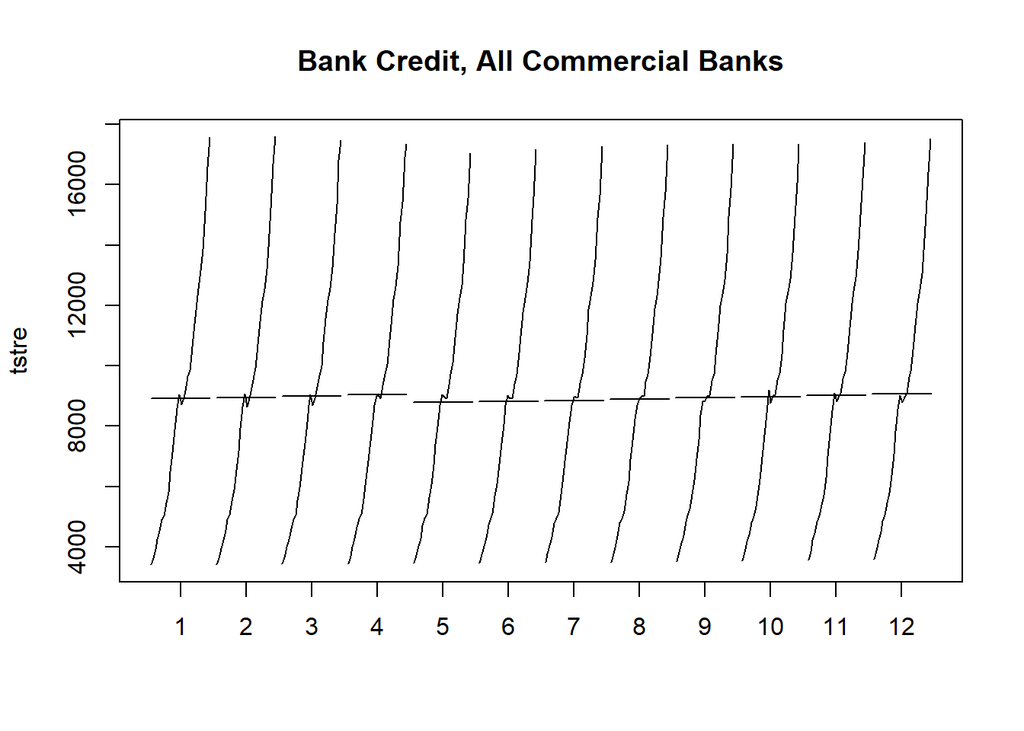

```r
monthplot(tstre, labels = NULL, times = time(tstre), phase = cycle(tstre), ylab = deparse1(substitute(tstre)), main = "Bank Credit, All Commercial Banks")
```

#### Wykres opóźnienia

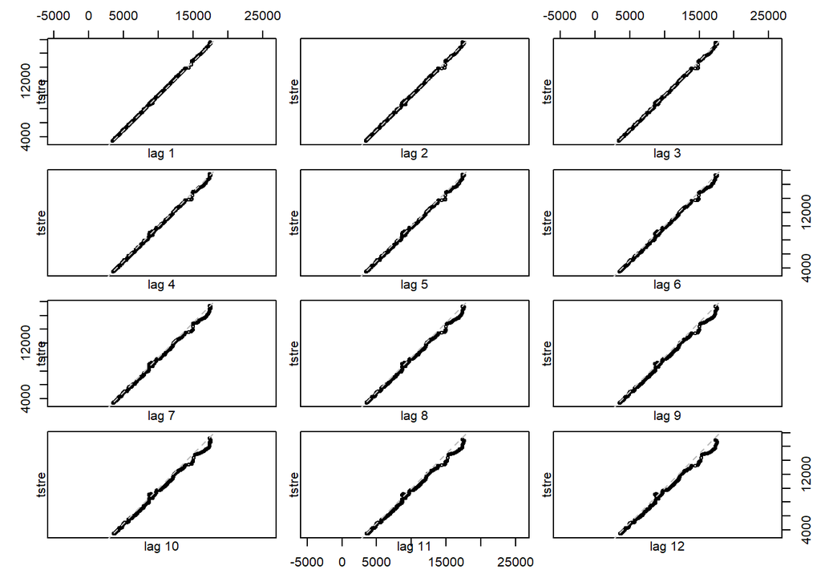

```r
lag.plot(tstre, lags=12)
```

#### Wykres sezonowy

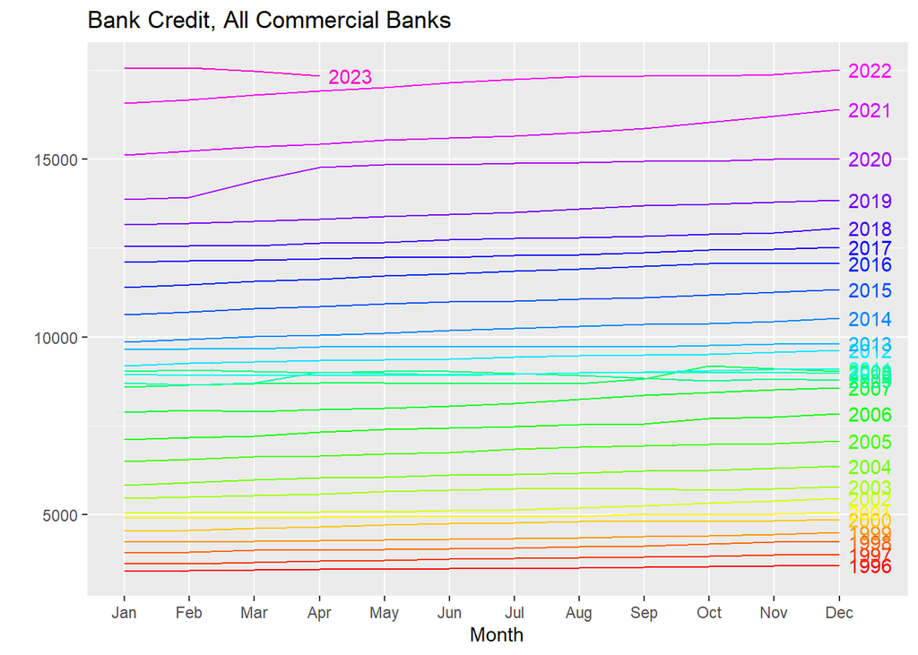

```r
ggseasonplot(tstre, col=rainbow(31), year.labels=TRUE, pch=31, main = "Bank Credit, All Commercial Banks")
```

W przypadku wartości wziętych kredytów możemy zauważyć, że w styczniu i lutym 2023 roku ich ilość była największa. Wykresy poszczególnych lat są raczej względem siebie podobnie ustawione co mówi nam to o trendzie zachodzącym w tych latach.

### Wykresy dla szeregu z sezonowością

#### Wykres czasowy

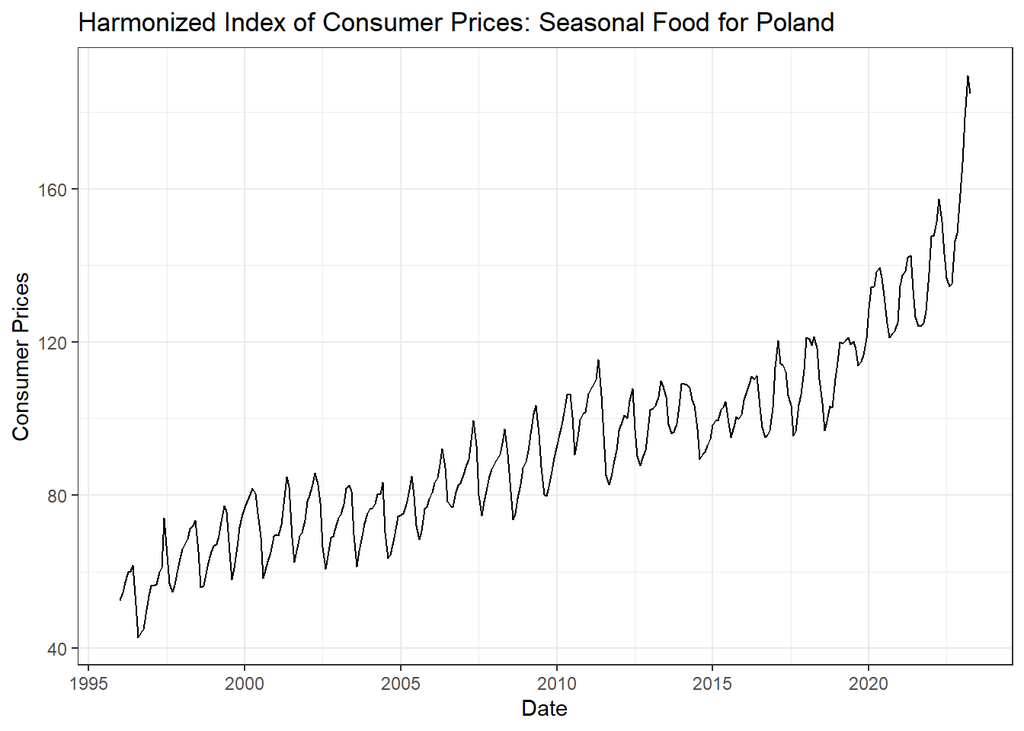

```r
autoplot(tssez, xlab = "Date", ylab = "Consumer Prices", main = "Harmonized Index of Consumer Prices: Seasonal Food for Poland") + theme_bw()
```

#### Acf

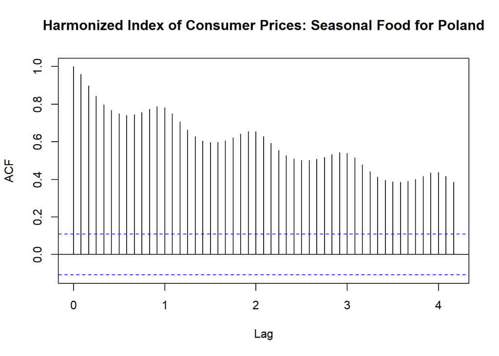

```r
acf(tssez, lag.max = 50, main = "Harmonized Index of Consumer Prices: Seasonal Food for Poland")
```

Na wykresie możemy zobaczyć regularne zmiany co oznacza, że występuje sezonowość.

#### Pacf

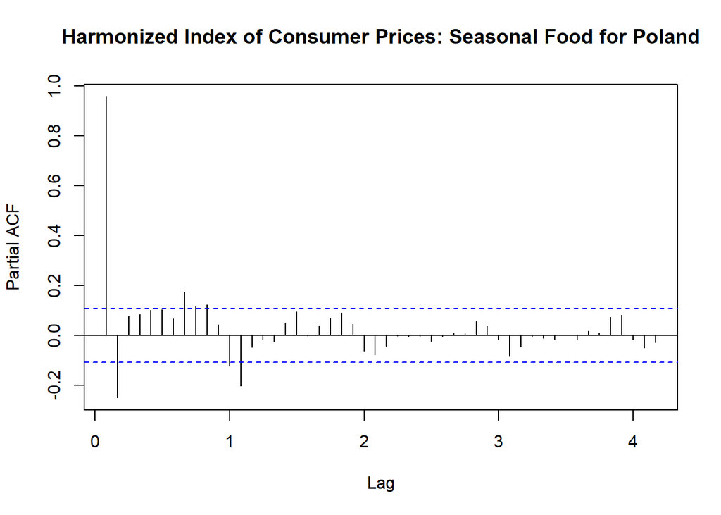

```r
pacf(tssez, lag.max = 50, main = "Harmonized Index of Consumer Prices: Seasonal Food for Poland")
```

#### Wykres miesięczny

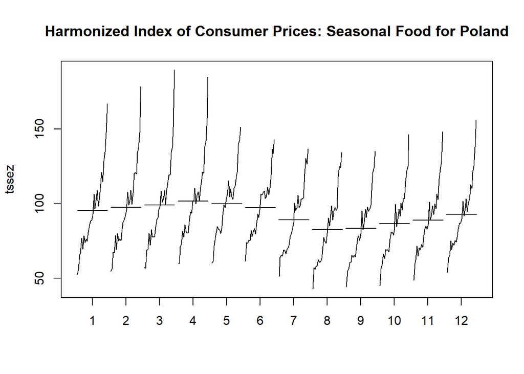

```r
monthplot(tssez, labels = NULL, times = time(tssez), phase = cycle(tssez), ylab = deparse1(substitute(tssez)), main = "Harmonized Index of Consumer Prices: Seasonal Food for Poland")
```

Możemy zauważyć, że zmiany są bardzo do siebie podobne. Pozioma linia oznacza średnią, możemy zauważyć, że największa jest dla kwietnia.

#### Wykres opóźnienia

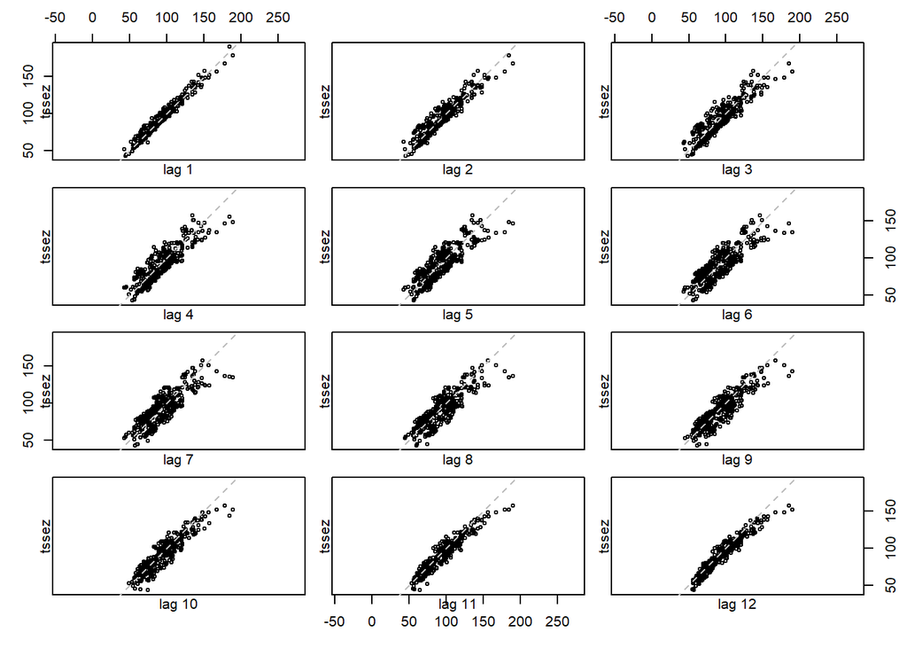

```r
lag.plot(tssez, lags=12)
```

#### Wykres sezonowy

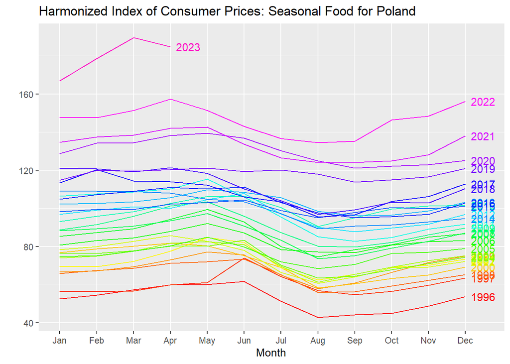

```r
ggseasonplot(tssez, col=rainbow(31), year.labels=TRUE, pch=19, main = "Harmonized Index of Consumer Prices: Seasonal Food for Poland")
```

Możemy zauważyć że najwyższa cena produktów sezonowych była w 2023 roku w Marcu. Wykresy poszczególnych lat pokazują sezonowość

## Dekompozycja

### Dekompozycja dla szeregu z trendem

#### Dekompozycja addtywna

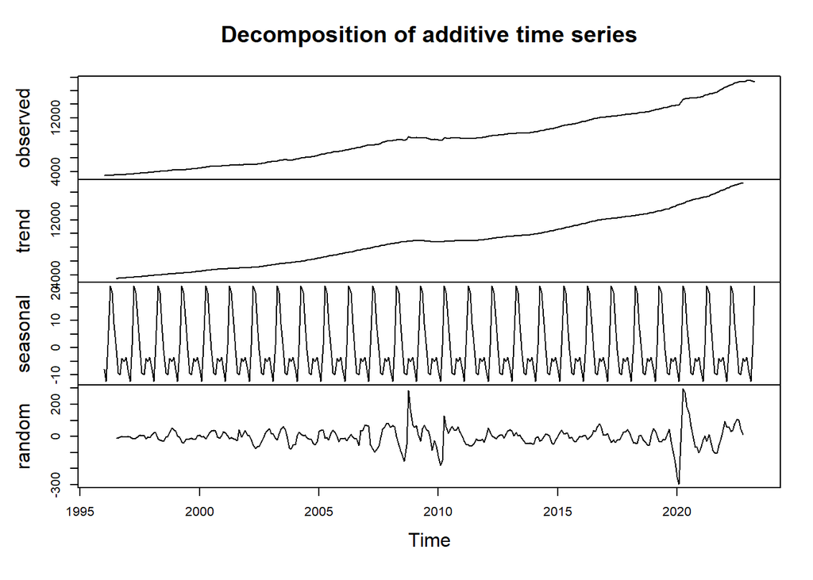

```r
daddtr <- decompose(tstre, type = "additive")
plot(daddtr)
```

#### Dekompozycja multiplikatywna

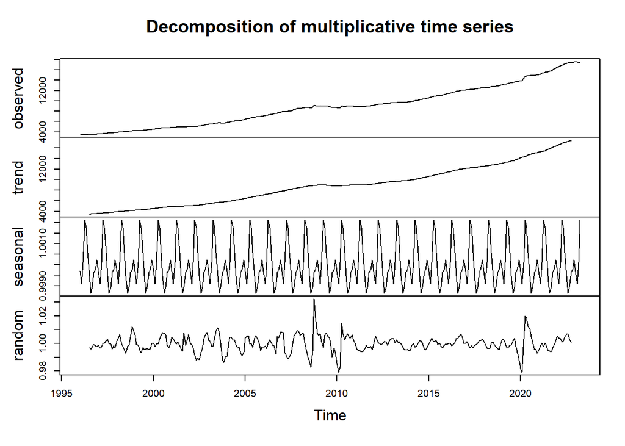

```r
dmulttr <- decompose(tstre, type = "multiplicative")
plot(dmulttr)
```

#### Dekompozycja na podstawie modelu regresji

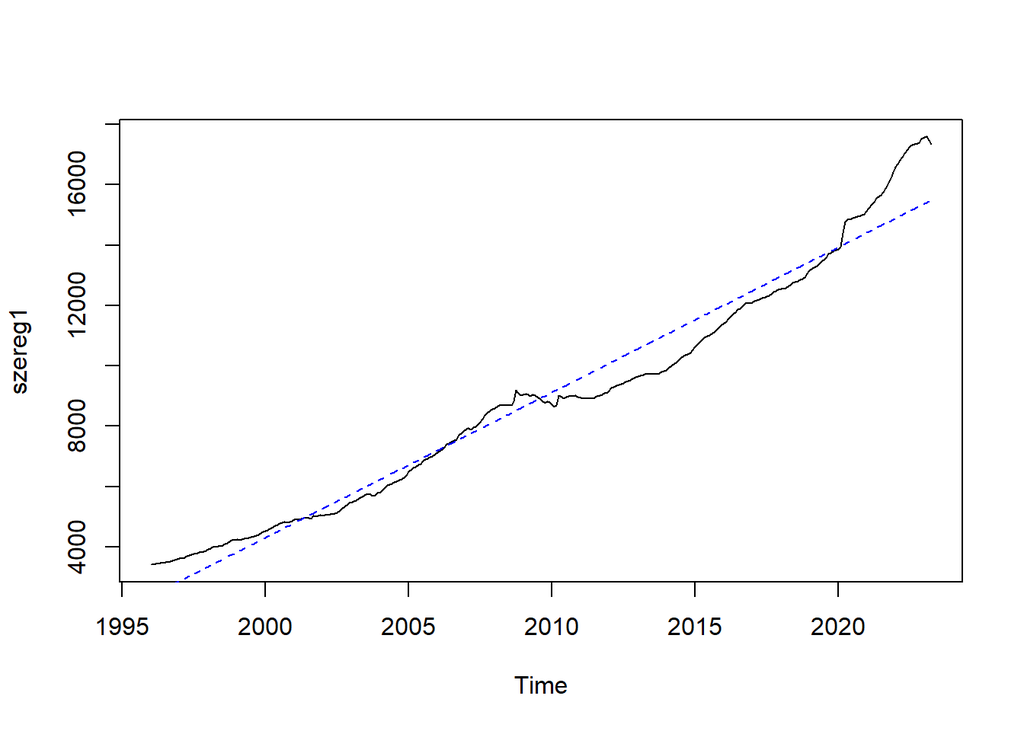

```r
szereg1 <- tstre
elec_model1 <- tslm(szereg1~trend)
plot(szereg1)
lines(fitted(elec_model1), col="blue", lty=2)
```

#### Dekompozycja za pomoca ruchomej sredniej

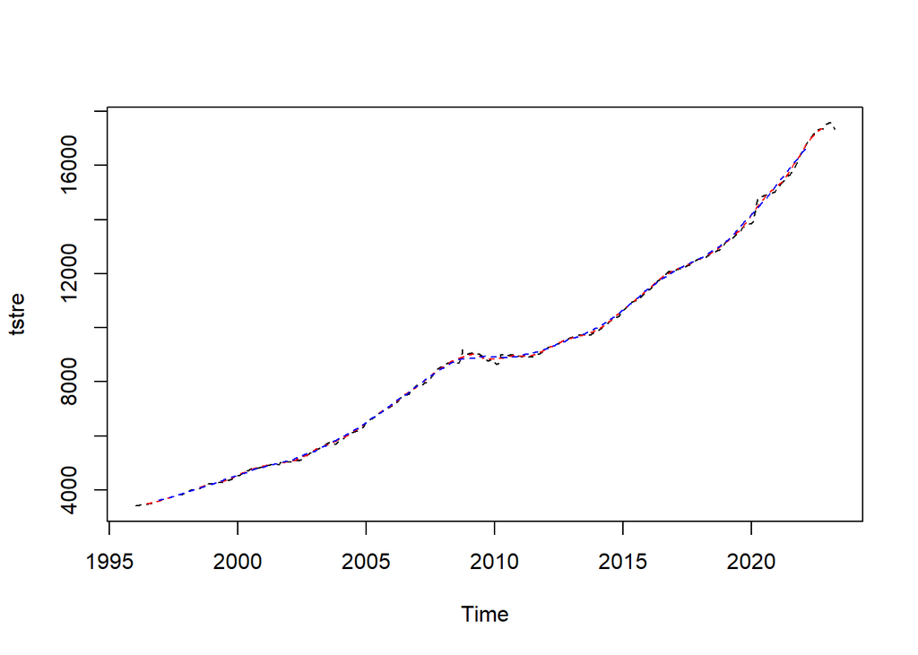

```r
tresr1 <- stats::filter(tstre, sides = 2, filter = rep(1/12,12))
tresr2 <- stats::filter(tstre, sides = 2, filter = rep(1/24,24))

plot(tstre, col="black", lty=2)
lines(tresr1, col="red", lty=2)
lines(tresr2, col="blue", lty=2)
```

### Dekompozycja dla szeregu z sezonowością

#### Dekompozycja addtywna

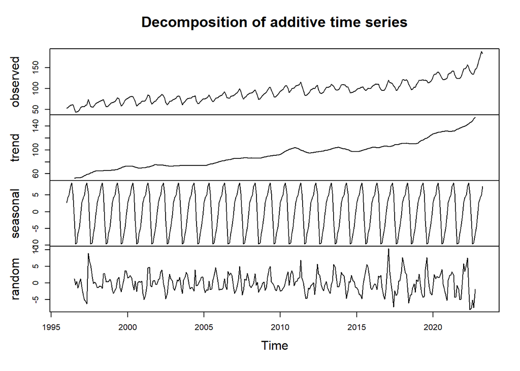

```r
daddsez <- decompose(tssez, type = "additive")
plot(daddsez)
```

#### Dekompozycja multiplikatywna

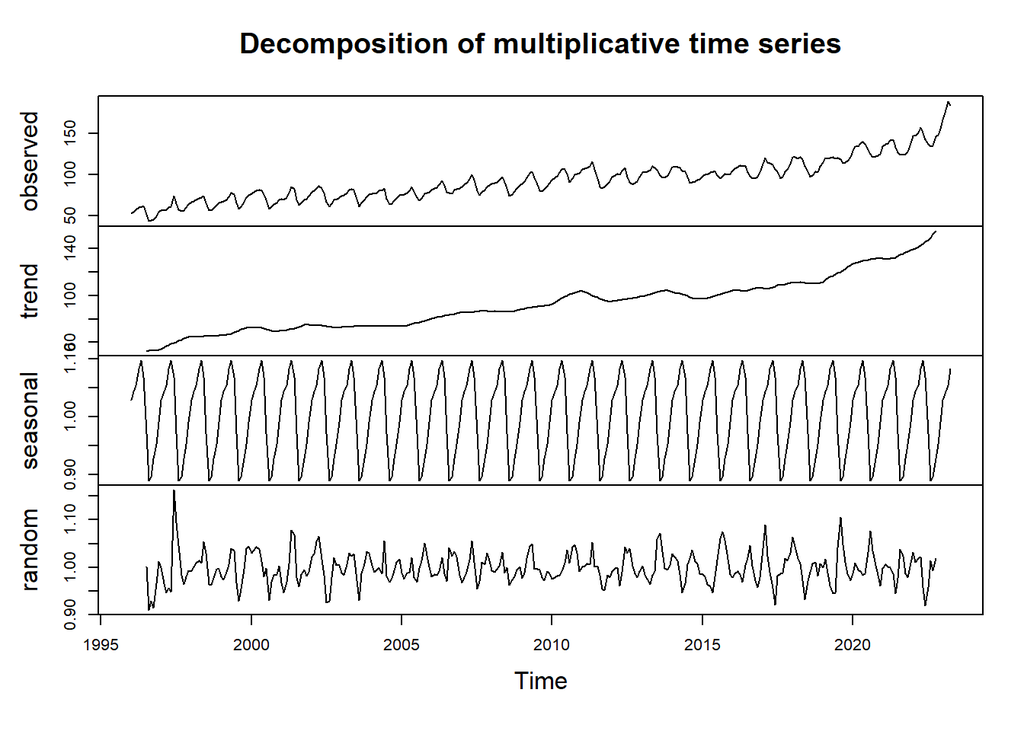

```r
dmultsez <- decompose(tssez, type = "multiplicative")
plot(dmultsez)
```

#### Dekompozycja na podstawie modelu regresji

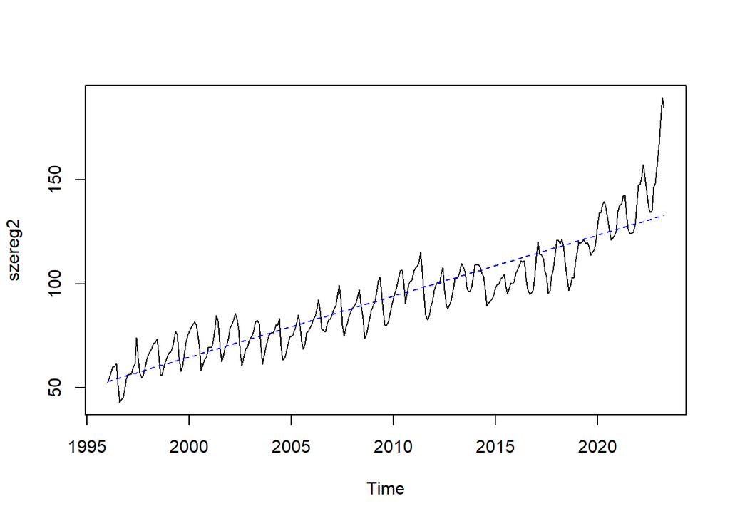

```r
szereg2 <- tssez
elec_model <- tslm(szereg2~trend)
plot(szereg2)
lines(fitted(elec_model), col="blue", lty=2)
```

#### Dekompozycja za pomoca ruchomej sredniej

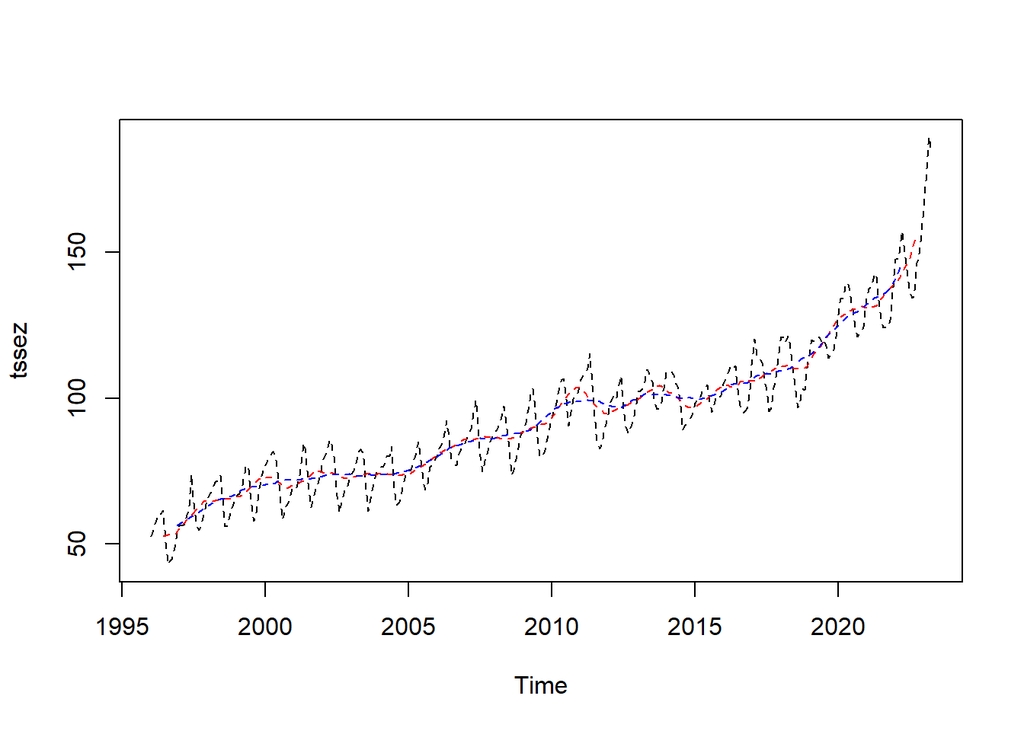

```r
sezsr1 <- stats::filter(tssez, sides = 2, filter = rep(1/12,12))
sezsr2 <- stats::filter(tssez, sides = 2, filter = rep(1/24,24))

plot(tssez, col="black", lty=2)
lines(sezsr1, col="red", lty=2)
lines(sezsr2, col="blue", lty=2)
```

## Eliminacja trendu, sezonowości

### Szereg z trendem

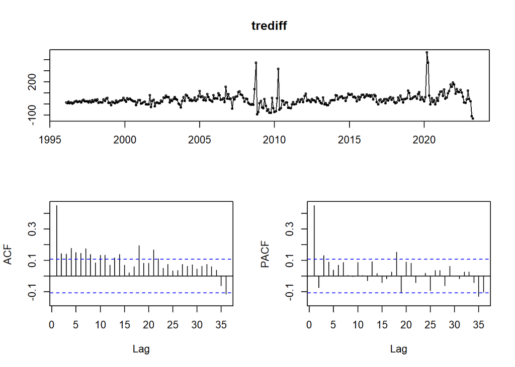

```r
trediff <- diff(tstre)
tsdisplay(trediff)
```

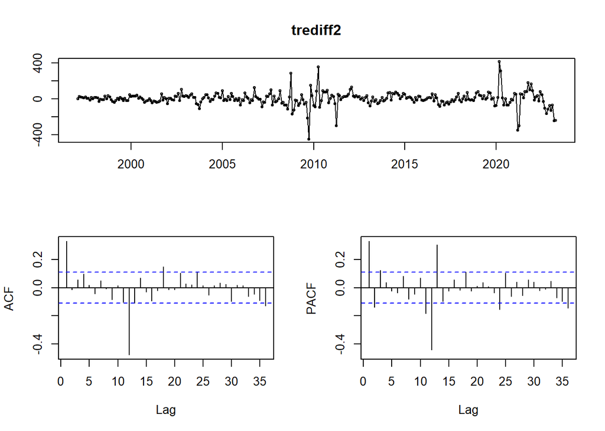

```r
#Nie ma już trendu
#Usuwamy sezonowość
trediff2 <- diff(trediff, lag = 12)
tsdisplay(trediff2)
```

### Szereg z sezonowością

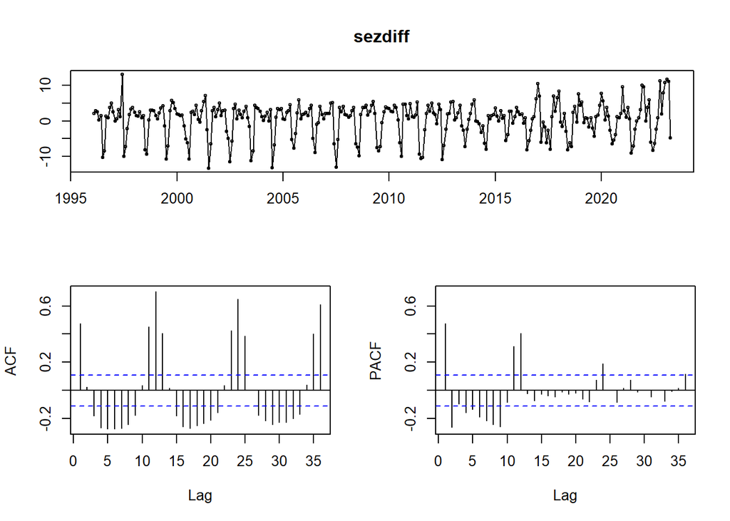

```r
sezdiff <- diff(tssez)
tsdisplay(sezdiff)
```

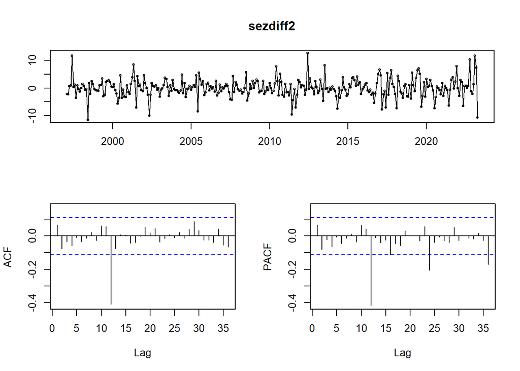

```r
#Nie ma już trendu
#Usuwamy sezonowość
sezdiff2 <- diff(sezdiff, lag = 12)
tsdisplay(sezdiff2)
```

## Uczynienie szeregów stacjonarnymi, sprawdzenie czy są one realizacją szumu białego, którego rzędu modele AR(p), MA(q) warto brać pod uwagę.

### Szereg z trendem

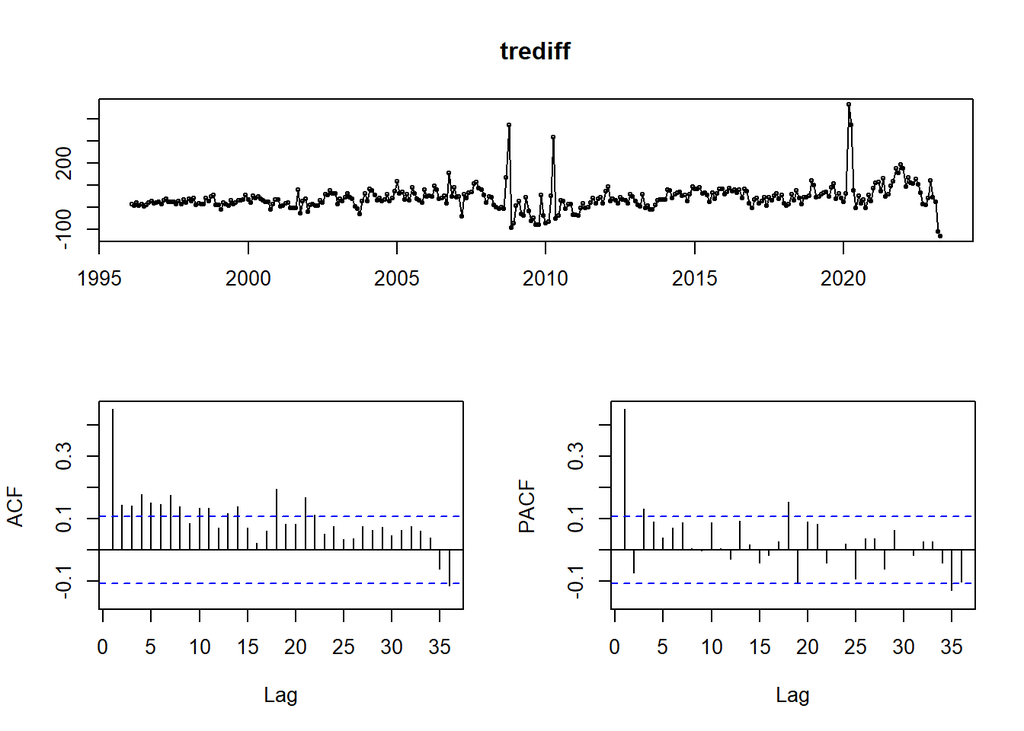

```r
trediff <- diff(tstre)
tsdisplay(trediff)
```

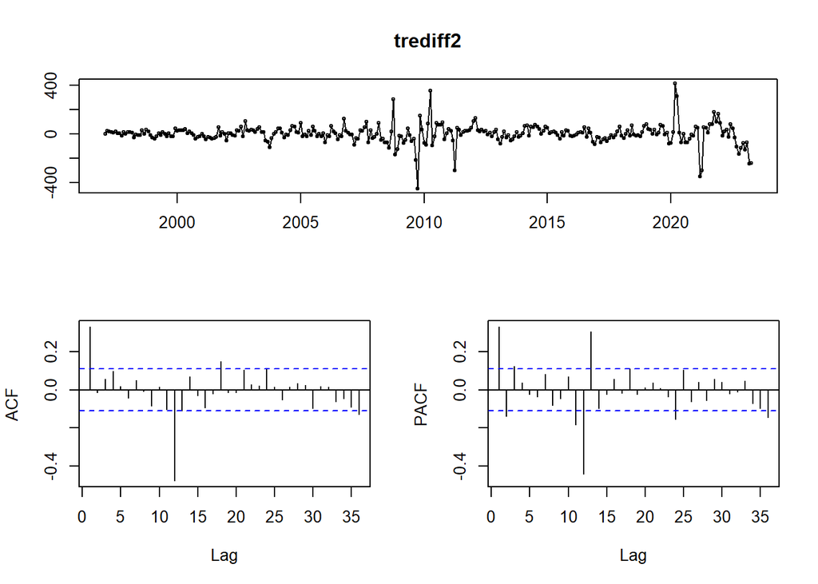

```r
#Nie ma już trendu
#Usuwamy sezonowość
trediff2 <- diff(trediff, lag = 12)
tsdisplay(trediff2)
```

```r
#AR(24) MA(12)
```

Szereg nie jest realizacja szumu bialego poniewaz wartosci korelacj sa duze i wystaja poza przedzialy ufnosci

### Szereg z sezonowością

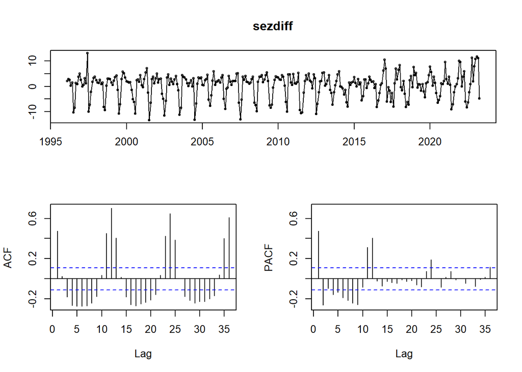

```r
sezdiff <- diff(tssez)
tsdisplay(sezdiff)
```

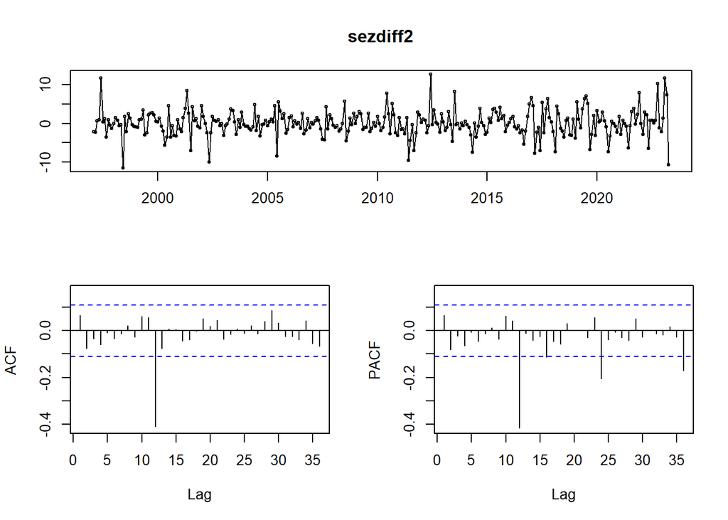

```r
#Nie ma już trendu
#Usuwamy sezonowość
sezdiff2 <- diff(sezdiff, lag = 12)
tsdisplay(sezdiff2)
```

```r
#AR(36) MA(12)
```

Szereg nie jest realizacja szumu bialego poniewaz wartosci korelacj sa duze i wystaja poza przedzialy ufnosci

## Wyznaczenie współczynników modelu AR, porównanie dopasowania z wykorzystaniem różnych metod estymacji, automatycznie dobrana wartość rzędu.

### Szereg z trendem

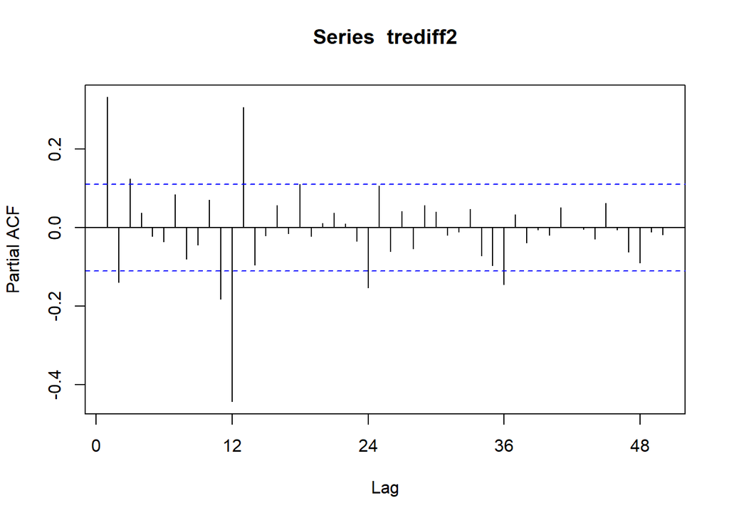

```r
#AR(36)
Pacf(trediff2, lag.max = 50)
```

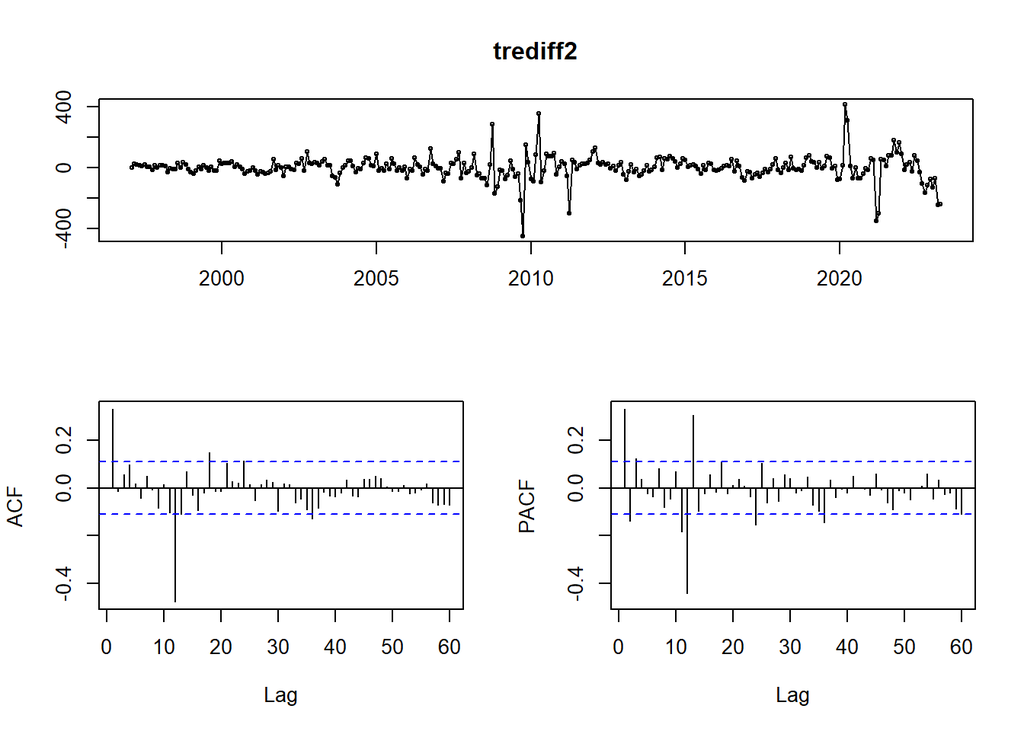

```r
tsdisplay(trediff2, lag.max = 60)
```

```r
trediff2yw <- ar(trediff2, aic = FALSE, order.max = 36, method=c("yule-walker"))
trediff2yw
```

```
##
## Call:
## ar(x = trediff2, aic = FALSE, order.max = 36, method = c("yule-walker"))
##
## Coefficients:
##       1        2        3        4        5        6        7        8
##  0.5070  -0.1881   0.0234   0.0845   0.0123  -0.0536   0.1237  -0.0387
##       9       10       11       12       13       14       15       16
## -0.0628   0.0696   0.0479  -0.6776   0.4364  -0.1438  -0.0015   0.0398
##      17       18       19       20       21       22       23       24
## -0.0371   0.1469  -0.0150  -0.0298   0.0748  -0.0290   0.0503  -0.2854
##      25       26       27       28       29       30       31       32
##  0.1474  -0.0992   0.0772  -0.0695   0.0386   0.0445   0.0080  -0.0351
##      33       34       35       36
##  0.0681  -0.0471  -0.0220  -0.1444
##
## Order selected 36  sigma^2 estimated as  3597
```

```r
trediff2mle <- ar(trediff2, aic = FALSE, order.max = 36, method=c("mle"))
trediff2mle
```

```
##
## Call:
## ar(x = trediff2, aic = FALSE, order.max = 36, method = c("mle"))
##
## Coefficients:
##       1        2        3        4        5        6        7        8
##  0.4792  -0.1580   0.0124   0.1058  -0.0117  -0.0683   0.1354  -0.0216
##       9       10       11       12       13       14       15       16
## -0.0455   0.0784   0.0037  -0.7545   0.4338  -0.1237   0.0143   0.0627
##      17       18       19       20       21       22       23       24
## -0.0800   0.1185  -0.0010  -0.0013   0.1081  -0.0174   0.0192  -0.4027
##      25       26       27       28       29       30       31       32
##  0.1672  -0.0606   0.1012  -0.0522   0.0308   0.0183   0.0115   0.0130
##      33       34       35       36
##  0.0753  -0.0533  -0.0512  -0.2844
##
## Order selected 36  sigma^2 estimated as  2779
```

```r
trediff2auto <- ar(trediff2, aic=TRUE)
trediff2auto
```

```
##
## Call:
## ar(x = trediff2, aic = TRUE)
##
## Coefficients:
##       1        2        3        4        5        6        7        8
##  0.4966  -0.1729   0.0248   0.0670   0.0433  -0.1471   0.1552  -0.0366
##       9       10       11       12       13       14
## -0.0737   0.0552   0.0394  -0.5561   0.3509  -0.0954
##
## Order selected 14  sigma^2 estimated as  3706
```

Funkcja automatyczna dobrała model rzędu (14), natomiast dwie poprzednie metody dobrały model rzędu (36).

### Szereg z sezonowością

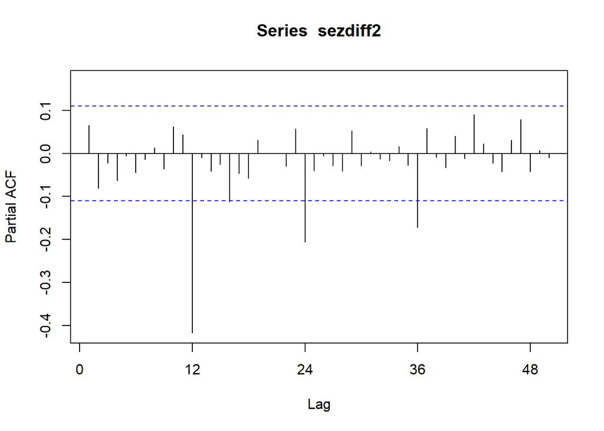

```r
#AR(12)
Pacf(sezdiff2, lag.max = 50)
```

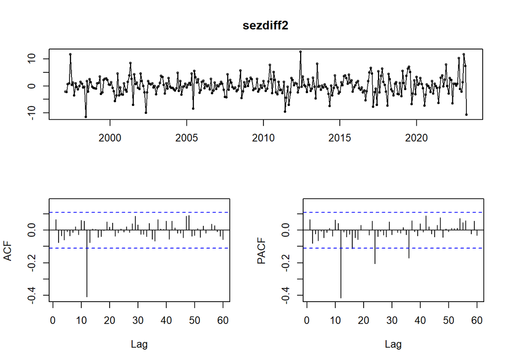

```r
tsdisplay(sezdiff2, lag.max = 60)
```

```r
sezdiff2yw <- ar(sezdiff2, aic = FALSE, order.max = 12, method=c("yule-walker"))
sezdiff2yw
```

```
##
## Call:
## ar(x = sezdiff2, aic = FALSE, order.max = 12, method = c("yule-walker"))
##
## Coefficients:
##       1        2        3        4        5        6        7        8
##  0.0842  -0.0620  -0.0368  -0.0541  -0.0095  -0.0553  -0.0150  -0.0048
##       9       10       11       12
## -0.0450   0.0233   0.0711  -0.4167
##
## Order selected 12  sigma^2 estimated as  9.264
```

```r
sesdiff2mle <- ar(sezdiff2, aic = FALSE, order.max = 12, method=c("mle"))
sesdiff2mle
```

```
##
## Call:
## ar(x = sezdiff2, aic = FALSE, order.max = 12, method = c("mle"))
##
## Coefficients:
##       1        2        3        4        5        6        7        8
##  0.0831  -0.0509  -0.0344  -0.0562  -0.0163  -0.0377  -0.0191  -0.0299
##       9       10       11       12
## -0.0422   0.0427   0.0834  -0.4821
##
## Order selected 12  sigma^2 estimated as  8.483
```

```r
sezdiff2auto <- ar(sezdiff2, aic=TRUE)
sezdiff2auto
```

```
##
## Call:
## ar(x = sezdiff2, aic = TRUE)
##
## Coefficients:
##       1        2        3        4        5        6        7        8
##  0.0842  -0.0620  -0.0368  -0.0541  -0.0095  -0.0553  -0.0150  -0.0048
##       9       10       11       12
## -0.0450   0.0233   0.0711  -0.4167
##
## Order selected 12  sigma^2 estimated as  9.264
```

Wszystkie metody dobrały taki sam model rzędu (12).

## Wyznaczenie współczynników dla modelu MA(q)

### Szereg z trendem

```r
#MA(18)
trearima <- Arima(trediff2, order = c(0,0,18))
summary(trearima)
```

```
## Series: trediff2
## ARIMA(0,0,18) with non-zero mean
##
## Coefficients:
##          ma1     ma2     ma3     ma4     ma5     ma6      ma7     ma8     ma9
##       0.4513  0.0690  0.0197  0.1099  0.0824  0.0029  -0.0002  0.0131  0.0260
## s.e.  0.0607  0.0703  0.0700  0.0646  0.0732  0.0707   0.0405  0.0416  0.0425
##         ma10     ma11     ma12     ma13     ma14     ma15     ma16     ma17
##       0.0345  -0.0152  -0.9547  -0.4668  -0.0948  -0.0269  -0.1215  -0.1469
## s.e.  0.0396   0.0452   0.0452   0.0608   0.0723   0.0762   0.0637   0.0833
##         ma18    mean
##       0.0181  1.7964
## s.e.  0.0694  0.6265
##
## sigma^2 = 2704:  log likelihood = -1698.18
## AIC=3436.36   AICc=3439.22   BIC=3511.42
##
## Training set error measures:
##                      ME     RMSE      MAE      MPE     MAPE      MASE
## Training set -0.3707375 50.40613 30.22527 100.1411 189.4283 0.3698923
##                      ACF1
## Training set 0.0008670431
```

```r
#MA(12)
trearima <- Arima(trediff2, order = c(0,0,12))
summary(trearima)
```

```
## Series: trediff2
## ARIMA(0,0,12) with non-zero mean
##
## Coefficients:
##          ma1     ma2     ma3     ma4     ma5     ma6     ma7     ma8     ma9
##       0.3101  0.0978  0.2350  0.2560  0.1143  0.2592  0.2639  0.1277  0.2975
## s.e.  0.0753  0.0948  0.0738  0.0664  0.0879  0.0798  0.0804  0.0969  0.0797
##         ma10    ma11     ma12     mean
##       0.3058  0.0963  -0.7294  -1.2983
## s.e.  0.0765  0.1054   0.0809   7.9864
##
## sigma^2 = 2994:  log likelihood = -1716.79
## AIC=3461.59   AICc=3462.99   BIC=3514.12
##
## Training set error measures:
##                      ME     RMSE      MAE      MPE     MAPE      MASE      ACF1
## Training set 0.01035961 53.57839 31.82043 119.8418 220.8197 0.3894136 0.1545715
```

## Wyznaczenie optymalnych modeli z wykorzystaniem funkcji auto.arima() oraz wyznaczenie ich współczynników

### Szereg z trendem

```r
autoAIC1 <- auto.arima(trediff2, ic ="aic")
#współczynniki
coef(autoAIC1)
```

```
##         ma1         ma2        sar1        sar2
##  0.51403437  0.09985259 -0.68590458 -0.24310297
```

```r
autoAICC1 <- auto.arima(trediff2, ic ="aicc")
#współczynniki
coef(autoAICC1)
```

```
##         ma1         ma2        sar1        sar2
##  0.51403437  0.09985259 -0.68590458 -0.24310297
```

```r
autoBIC1 <- auto.arima(trediff2, ic ="bic")
#współczynniki
coef(autoBIC1)
```

```
##        ma1       sar1       sar2
##  0.4630944 -0.6680037 -0.2341600
```

### Szereg z sezonowością

```r
autoAIC2 <- auto.arima(sezdiff2, ic ="aic")
#współczynniki
coef(autoAIC2)
```

```
##         ma1        sma1
##  0.09662156 -0.69474597
```

```r
autoAICC2 <- auto.arima(sezdiff2, ic ="aicc")
#współczynniki
coef(autoAICC2)
```

```
##         ma1        sma1
##  0.09662156 -0.69474597
```

```r
autoBIC2 <- auto.arima(sezdiff2, ic ="bic")
#współczynniki
coef(autoBIC2)
```

```
##       sma1
## -0.6887433
```

## Porównanie analizowanych modeli, wybór najlepszego

### Szereg z trendem

```r
summary(autoAIC1)
```

```
## Series: trediff2
## ARIMA(0,0,2)(2,0,0)[12] with zero mean
##
## Coefficients:
##         ma1     ma2     sar1     sar2
##       0.514  0.0999  -0.6859  -0.2431
## s.e.  0.059  0.0615   0.0570   0.0564
##
## sigma^2 = 3507:  log likelihood = -1733.59
## AIC=3477.19   AICc=3477.38   BIC=3495.95
##
## Training set error measures:
##                    ME     RMSE      MAE      MPE     MAPE     MASE         ACF1
## Training set 2.127492 58.84326 36.48452 101.2724 200.6909 0.446492 -0.002963007
```

```r
summary(autoAICC1)
```

```
## Series: trediff2
## ARIMA(0,0,2)(2,0,0)[12] with zero mean
##
## Coefficients:
##         ma1     ma2     sar1     sar2
##       0.514  0.0999  -0.6859  -0.2431
## s.e.  0.059  0.0615   0.0570   0.0564
##
## sigma^2 = 3507:  log likelihood = -1733.59
## AIC=3477.19   AICc=3477.38   BIC=3495.95
##
## Training set error measures:
##                    ME     RMSE      MAE      MPE     MAPE     MASE         ACF1
## Training set 2.127492 58.84326 36.48452 101.2724 200.6909 0.446492 -0.002963007
```

```r
summary(autoBIC1)
```

```
## Series: trediff2
## ARIMA(0,0,1)(2,0,0)[12] with zero mean
##
## Coefficients:
##          ma1     sar1     sar2
##       0.4631  -0.6680  -0.2342
## s.e.  0.0465   0.0562   0.0565
##
## sigma^2 = 3529:  log likelihood = -1734.92
## AIC=3477.84   AICc=3477.97   BIC=3492.85
##
## Training set error measures:
##                    ME     RMSE      MAE      MPE     MAPE      MASE       ACF1
## Training set 2.386364 59.12206 36.86472 108.0666 201.1889 0.4511449 0.03868766
```

Najlepszym modelem będzie ARIMA(0,0,2)(2,0,0) wyznaczona przez dwa pierwsze krtyteria z dopasowaniem z aic oraz aicc.

### Szereg z sezonowością

```r
summary(autoAIC2)
```

```
## Series: sezdiff2
## ARIMA(0,0,1)(0,0,1)[12] with zero mean
##
## Coefficients:
##          ma1     sma1
##       0.0966  -0.6947
## s.e.  0.0609   0.0500
##
## sigma^2 = 7.733:  log likelihood = -772.09
## AIC=1550.19   AICc=1550.26   BIC=1561.45
##
## Training set error measures:
##                      ME     RMSE      MAE MPE MAPE     MASE         ACF1
## Training set 0.09061414 2.772042 2.059236 NaN  Inf 0.512989 -0.006664598
```

```r
summary(autoAICC2)
```

```
## Series: sezdiff2
## ARIMA(0,0,1)(0,0,1)[12] with zero mean
##
## Coefficients:
##          ma1     sma1
##       0.0966  -0.6947
## s.e.  0.0609   0.0500
##
## sigma^2 = 7.733:  log likelihood = -772.09
## AIC=1550.19   AICc=1550.26   BIC=1561.45
##
## Training set error measures:
##                      ME     RMSE      MAE MPE MAPE     MASE         ACF1
## Training set 0.09061414 2.772042 2.059236 NaN  Inf 0.512989 -0.006664598
```

```r
summary(autoBIC2)
```

```
## Series: sezdiff2
## ARIMA(0,0,0)(0,0,1)[12] with zero mean
##
## Coefficients:
##          sma1
##       -0.6887
## s.e.   0.0498
##
## sigma^2 = 7.775:  log likelihood = -773.33
## AIC=1550.67   AICc=1550.71   BIC=1558.17
##
## Training set error measures:
##                    ME     RMSE      MAE MPE MAPE      MASE       ACF1
## Training set 0.102478 2.783863 2.075312 NaN  Inf 0.5169938 0.07955126
```